# Practica_2

Aniol, Omar, Marcel

2026-01-12

## Pregunta 1:

### 1. Descargar la página web de la URL indicada, y almacenarlo en un formato de R apto para ser tratado.

> El primer paso para realizar tareas de crawling y scraping es poder descargar los datos de la web. Para esto usaremos la capacidad de R y de sus librerías (httr y XML) para descargar webs y almacenarlas en variables que podamos convertir en un formato fácil de analizar (p.e. de HTML a XML).

Usamos el link para obtener los contenidos de la web y posteriormente parsearlo.

```r
LINK  <- "https://www.mediawiki.org/wiki/MediaWiki"
LINK_BASE  <- "https://www.mediawiki.org"
res <- GET(LINK)
html_content <- content(res, "text", encoding = "UTF-8")
```

### 2. Analizar el contenido de la web, buscando el título de la página (que en HTML se etiqueta como “title”).

> En las cabeceras web encontramos información como el título, los ficheros de estilo visual, y meta-información como el nombre del autor de la página, una descripción de esta, el tipo de codificación de esta, o palabras clave que indican qué tipo de información contiene la página. Una vez descargada la página, y convertida a un formato analizable (como XML), buscaremos los elementos de tipo `title`. P.e. `<title>Titulo de Página</title>`.

```r
doc <- htmlParse(html_content, asText = TRUE)
titulos <- xpathSApply(doc, "//title", xmlValue, "title")
print(titulos)
```

```
## [1] "MediaWiki"
```

### 3. Analizar el contenido de la web, buscando todos los enlaces (que en HTML se etiquetan como “a”), buscando el texto del enlace, así como la URL.

> Vamos a extraer, usando las funciones de búsqueda XML, todos los enlaces que salen de esta página con tal de listarlos y poder descargarlas más tarde. Sabemos que estos son elementos de tipo `<a>`, que tienen el atributo “href” para indicar la URL del enlace. P.e. `<a href = ‘enlace’>Texto del Enlace</a>` . Del enlace nos quedaremos con la URL de destino y con el valor del enlace (texto del enlace).

Para resolver este problema, primero tenemos que parsear la pagina. Luego usamos las funciones de la librería XML para obtener los enlaces y el texto guardado en ellas.

```r
doc <- htmlParse(html_content, asText = TRUE)
enlaces <- xpathSApply(doc, "//a", xmlGetAttr, "href")
text_enlace <- xpathSApply(doc, "//a", xmlValue)
is.null(text_enlace)
```

```
## [1] FALSE
```

Imprimimos los 10 primeros links:

```r
head(text_enlace, 10)
```

```
##  [1] "Jump to content"  "Main page"        "Get MediaWiki"    "Get extensions"
##  [5] "Tech blog"        "Contribute"       "User help"        "FAQ"
##  [9] "Technical manual" "Support desk"
```

### 4. Generar una tabla con cada enlace encontrado, indicando el texto que acompaña el enlace, y el número de veces que aparece un enlace con ese mismo objetivo.

> En este paso nos interesa reunir los datos obtenidos en el anterior paso. Tendremos que comprobar, para cada enlace, cuantas veces aparece.

Creamos un dataframe que contiene las url y los enlaces.

```r
df_enlaces <- data.frame(enlace = enlaces, texto = text_enlace, stringsAsFactors = FALSE )
```

En esta sección nos dimos cuenta de que existen algunos links relacionados a imagenes que thenen una url = `#`. Como no són links normales, tomamos la decisión de quitarlos del dataset.

```r
df_enlaces <- df_enlaces[df_enlaces$enlace!="#",]
```

Posteriormente usamos la función `count` de *dyplr* para deduplicar las entradas repetidas y contar el numero de repeticiones.

```r
df_enlaces_dedup <- df_enlaces %>% count(enlace, texto)
datatable(df_enlaces_dedup)
```

|  | enlace | texto | n |
| --- | --- | --- | --- |
| 1 | #bodyContent | Jump to content | 1 |
| 2 | //commons.wikimedia.org/wiki/Special:UploadWizard | Upload file | 1 |
| 3 | //www.mediawiki.org/w/index.php?title=MediaWiki&amp;mobileaction=toggle_view_mobile | Mobile view | 1 |
| 4 | /w/index.php?title=MediaWiki&amp;action=edit | View source | 2 |
| 5 | /w/index.php?title=MediaWiki&amp;action=history | View history | 2 |
| 6 | /w/index.php?title=MediaWiki&amp;action=info | Page information | 1 |
| 7 | /w/index.php?title=MediaWiki&amp;oldid=6287429 | Permanent link | 1 |
| 8 | /w/index.php?title=MediaWiki&amp;printable=yes | Printable version | 1 |
| 9 | /w/index.php?title=Special:Book&amp;bookcmd=book_creator&amp;referer=MediaWiki | Create a book | 1 |
| 10 | /w/index.php?title=Special:CiteThisPage&amp;page=MediaWiki&amp;id=6287429&amp;wpFormIdentifier=titleform | Cite this page | 1 |

[output cut: 167 more lines]

### 5. Para cada enlace, seguirlo e indicar si está activo (podemos usar el código de status HTTP al hacer una petición a esa URL).

> En este paso podemos usar la función HEAD de la librería “httr”, que en vez de descargarse la página como haría GET, solo consultamos los atributos de la página o fichero destino.

> HEAD nos retorna una lista de atributos, y de entre estos hay uno llamado “header” que contiene más atributos sobre la página buscada. Si seguimos podemos encontrar el “`status_code`” en “`resultado$status_code`”. El “status_code” nos indica el resultado de la petición de página o fichero. Este código puede indicar que la petición ha sido correcta (`200`), que no se ha encontrado (`404`), que el acceso está restringido (`403`), etc.
> - Tened en cuenta que hay enlaces con la URL relativa, con forma `/xxxxxx/xxxxx/a.html`. En este caso, podemos indicarle como “handle” el dominio de la página que estamos tratando, o añadirle el dominio a la URL con la función “paste”.
> - Tened en cuenta que puede haber enlaces externos con la URL absoluta, con forma “http://xxxxxx/xxxx/a.html” (o https), que los trataremos directamente.
> - Tened en cuenta que puede haber enlaces que apunten a subdominios distintos, con forma “//subdominio/xxxx/xxxx/a.html”. En este caso podemos adjuntarle el prefijo “https:” delante, convirtiendo la URL en absoluta.
> - Tened en cuenta URLS internas con tags, como por ejemplo “#search-p”. Estos apuntan a la misma página en la que estamos, pero diferente altura de página. Equivale a acceder a la URL relativa de la misma página en la que estamos.

> Es recomendado poner un tiempo de espera entre petición y petición de pocos segundos (comando “Sys.sleep”), para evitar ser “baneados” por el servidor. Para poder examinar las URLs podemos usar expresiones regulares, funciones como “grep”, o mirar si en los primeros caracteres de la URL encontramos “//” o “http”. Para tratar las URLs podemos usar la ayuda de la función “paste”, para manipular cadenas de caracteres y poder añadir prefijos a las URLs si fuera necesario.

Primero hemos creado una función que obtiene la url absoluta independientemente del input.

```r
normalitza_url <- function(u, base_url) {
  if (is.na(u) || u == "") return(NA)

  if (grepl("^#", u)) {
    return(base_url)
  }

  if (grepl("^http", u)) {
    return(u)
  }

  if (grepl("^//", u)) {
    return(paste0("https:", u))
  }

  if (grepl("^/", u)) {
    return(paste0(base_url, u))
  }

  return(NA)
}
```

Hemos añadido las url absolutas a una nueva columna del dataframe.

Con la url absoluta hemos usado la función HEAD para determinar el status del enlace y lo hemos guardado en una columna del dataframe.

```r
df_enlaces_dedup$status <- NA
df_enlaces_dedup$url_abs <- NA

for (i in 1:nrow(df_enlaces_dedup)) {
  u <- df_enlaces_dedup$enlace[i]

  url_abs <- normalitza_url(u, LINK_BASE)

  df_enlaces_dedup$url_abs[i] <- url_abs

  resultat <- try(HEAD(url_abs), silent = TRUE)
  if (inherits(resultat, "try-error")) { df_enlaces_dedup$status[i] <- NA }
  else{df_enlaces_dedup$status[i] <- resultat$status_code}

  Sys.sleep(0.1)
}
datatable(df_enlaces_dedup)
```

|  | enlace | texto | n | status | url_abs |
| --- | --- | --- | --- | --- | --- |
| 1 | #bodyContent | Jump to content | 1 | 200 | https://www.mediawiki.org |
| 2 | //commons.wikimedia.org/wiki/Special:UploadWizard | Upload file | 1 | 200 | https://commons.wikimedia.org/wiki/Special:UploadWizard |
| 3 | //www.mediawiki.org/w/index.php?title=MediaWiki&amp;mobileaction=toggle_view_mobile | Mobile view | 1 | 200 | https://www.mediawiki.org/w/index.php?title=MediaWiki&amp;mobileaction=toggle_view_mobile |
| 4 | /w/index.php?title=MediaWiki&amp;action=edit | View source | 2 | 200 | https://www.mediawiki.org/w/index.php?title=MediaWiki&amp;action=edit |
| 5 | /w/index.php?title=MediaWiki&amp;action=history | View history | 2 | 200 | https://www.mediawiki.org/w/index.php?title=MediaWiki&amp;action=history |
| 6 | /w/index.php?title=MediaWiki&amp;action=info | Page information | 1 | 200 | https://www.mediawiki.org/w/index.php?title=MediaWiki&amp;action=info |
| 7 | /w/index.php?title=MediaWiki&amp;oldid=6287429 | Permanent link | 1 | 200 | https://www.mediawiki.org/w/index.php?title=MediaWiki&amp;oldid=6287429 |
| 8 | /w/index.php?title=MediaWiki&amp;printable=yes | Printable version | 1 | 200 | https://www.mediawiki.org/w/index.php?title=MediaWiki&amp;printable=yes |
| 9 | /w/index.php?title=Special:Book&amp;bookcmd=book_creator&amp;referer=MediaWiki | Create a book | 1 | 200 | https://www.mediawiki.org/w/index.php?title=Special:Book&amp;bookcmd=book_creator&amp;referer=MediaWiki |
| 10 | /w/index.php?title=Special:CiteThisPage&amp;page=MediaWiki&amp;id=6287429&amp;wpFormIdentifier=titleform | Cite this page | 1 | 200 | https://www.mediawiki.org/w/index.php?title=Special:CiteThisPage&amp;page=MediaWiki&amp;id=6287429&amp;wpFormIdentifier=titleform |

[output cut: 167 more lines]

## Pregunta 2

### 1. Un histograma con la frecuencia de aparición de los enlaces, pero separado por URLs absolutas (con “http…”) y URLs relativas.

Hemos creado una nueva columna en el dataframe que indica si la url original era absoluta o no. A partir de esta columna i la de veces que aparece cada enlace hemos generado un histograma.

El cian muestra el numero de urls absolutas y el naranja muestra el número de urls relativas.

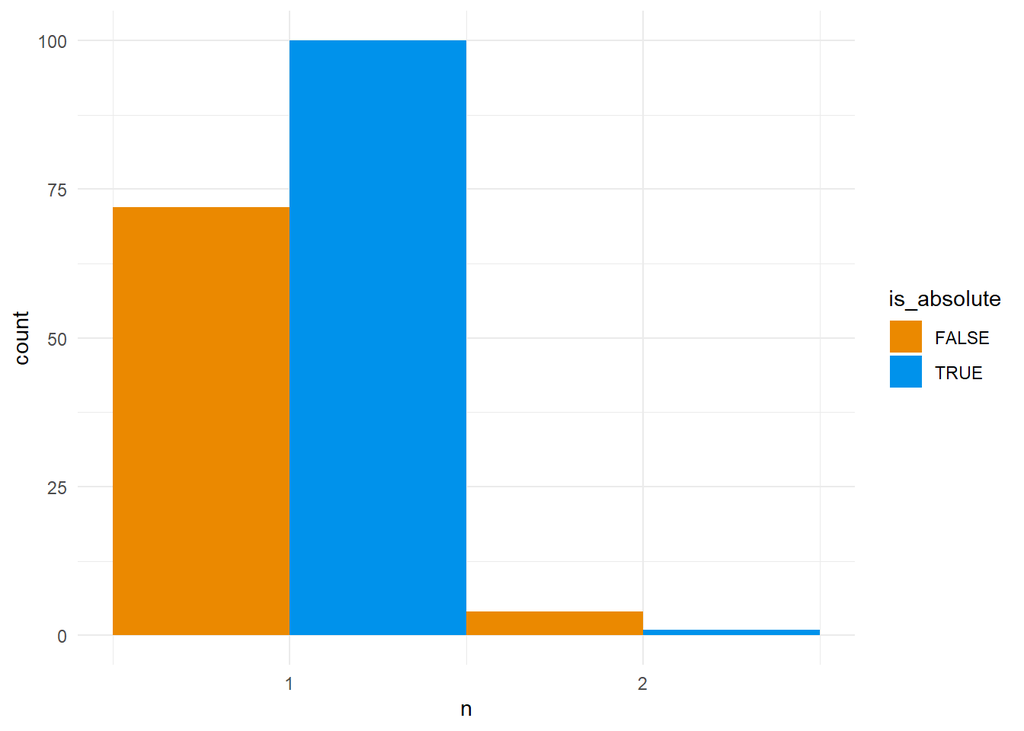

```r
df_enlaces_dedup$is_absolute <- NA

for (i in 1:nrow(df_enlaces_dedup)) {
  u <- df_enlaces_dedup$enlace[i]
  if (grepl("^http", u)) {
    df_enlaces_dedup$is_absolute[i] <- TRUE
  }
  else{
    df_enlaces_dedup$is_absolute[i] <- FALSE
  }

}

ggplot(df_enlaces_dedup, aes(x = n, fill = is_absolute)) + geom_histogram(alpha = 1, position = "dodge", bins = 2) + scale_fill_manual(values = c("TRUE" = "#0092EB", "FALSE" = "#EB8900")) + theme_minimal() + scale_x_continuous(breaks=c(1,2))
```

### 2. Un gráfico de barras indicando la suma de enlaces que apuntan a otros dominios o servicios (distinto a https://www.mediawiki.org en el caso de ejemplo) vs. la suma de los otros enlaces.

> Aquí queremos distinguir enlaces que apuntan a mediawiki versus el resto. Sabemos que las URLs relativas ya apuntan dentro, por lo tanto hay que analizar las URLs absolutas y comprobar que apunten a https://www.mediawiki.org.

En esta sección, añadimos una nueva columna en el dataframe que indica si la url redirije al propio dominio o no.

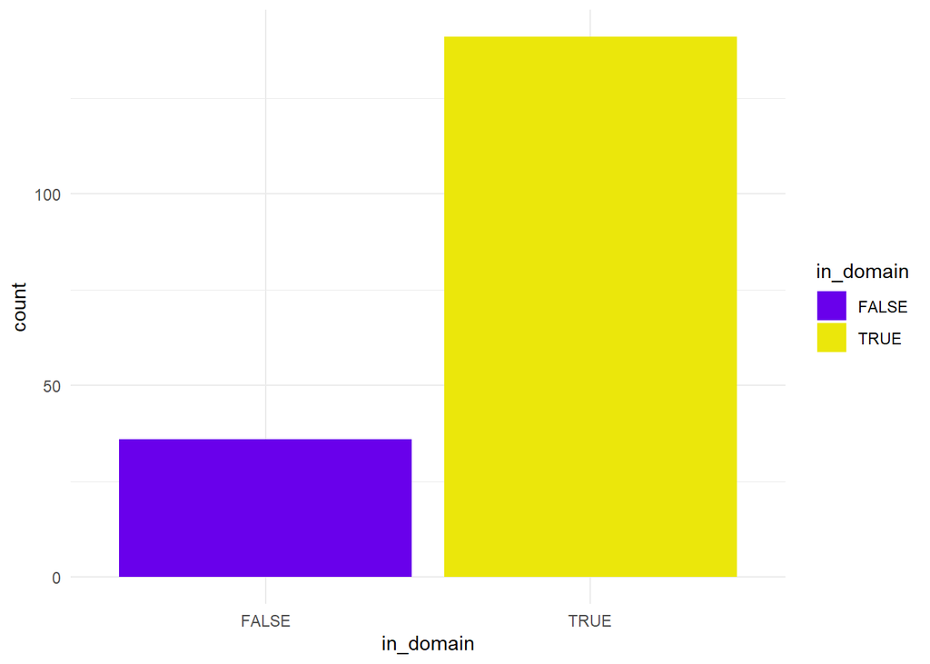

```r
df_enlaces_dedup$in_domain <- NA
for (i in 1:nrow(df_enlaces_dedup)) {
  u <- df_enlaces_dedup$url_abs[i]
  if (grepl("mediawiki.org", u)) {
    df_enlaces_dedup$in_domain[i] <- TRUE
  }
  else{
    df_enlaces_dedup$in_domain[i] <- FALSE
  }

}


ggplot(df_enlaces_dedup, aes(x = in_domain)) +
  geom_bar(aes(fill = in_domain)) +
  scale_fill_manual(values = c("TRUE" = "#EBE70B", "FALSE" = "#6900EB")) +
  theme_minimal()
```

### 3. Un gráfico de tarta (pie chart) indicando los porcentajes de Status de nuestro análisis.

> Por ejemplo, si hay 6 enlaces con status “200” y 4 enlaces con status “`404`”, la tarta mostrará un 60% con la etiqueta “`200`” y un 40% con la etiqueta “`404`”. Este gráfico lo uniremos a los anteriores. El objetivo final es obtener una imagen que recopile los gráficos generados.

Primeramente hacemos un conteo de el número de cada status code y luego hacemos un piechart con ello.

En nuestro caso, todos los códigos són `200`.

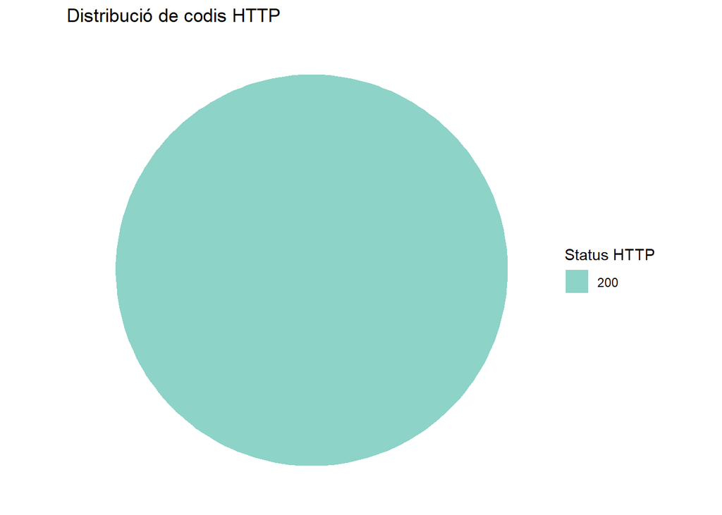

```r
df_status <- df_enlaces_dedup %>% count(status)

ggplot(df_status, aes(x = "", y = n, fill = factor(status))) +
  geom_col(width = 1) +
  coord_polar(theta = "y") +
  theme_void() +
  scale_fill_brewer(palette = "Set3") +
  labs(fill = "Status HTTP",
       title = "Distribució de codis HTTP")
```